# Cleaning and Organizing Data using R

Nov 28, 2023

## What is R ?

- Open source statistical programming language.
  - A collaborative effort
  - many people contribute
- to include a package first we need to install the package

```r
  install.packages("package-name")
  library("package-name")
```

- Install the package only once, but you have to include it every time you start R
- You want to contribute? Build a package and upload it to Comprehensive R Archive Network, CRAN
- Its free, it runs on Windows-MAC-Linux/Unix

## Install R and RStudio

- Get R from http://cran.r-project.org/
- Install a typesetting software latex or Miktex from http://miktex.org/download
  - for MAC user it would be MacTex
- Get RStudio desktop version from http://www.rstudio.com/
  - RStuio provides convenient environment.
- Its all free
- Please make sure you install them in the sequence mentioned above

## Modes of data in R

- numeric
- character
- logical
- factor
- ordered
- complex
- raw
- NULL

How do you get the mode?

```r
mode(5+3i)
```

```
## [1] "complex"
```

Checking and changing the mode

```r
x <- "5.42"
is.numeric(x)
```

```
## [1] FALSE
```

```r
y <- as.numeric("5.44")
mode(y)
```

```
## [1] "numeric"
```

```r
is.logical(FALSE)
```

```
## [1] TRUE
```

## R data structures

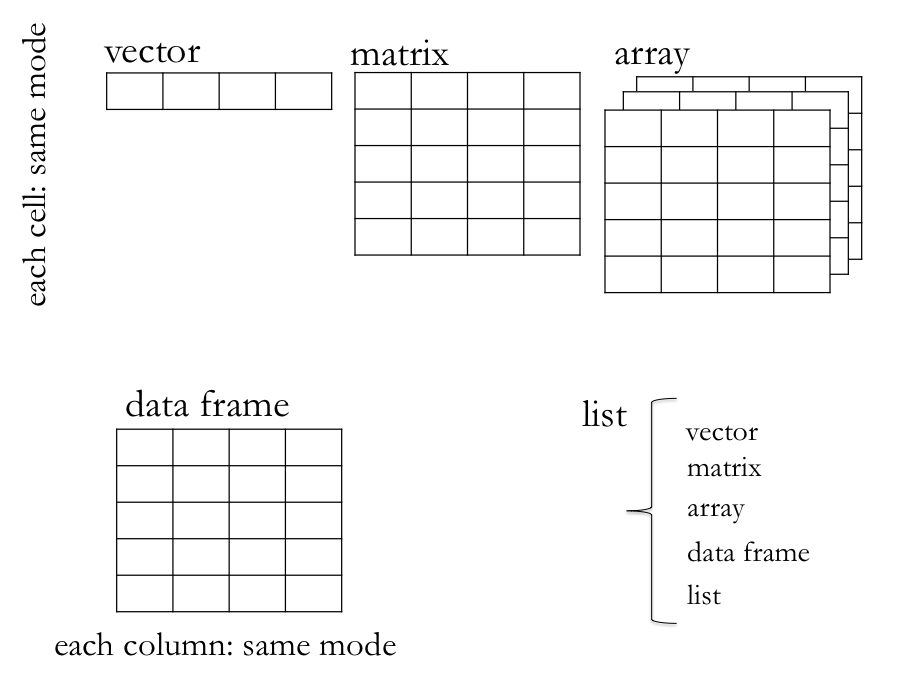

## Hands on exercise

- Now execute the following codes and discuss what is going on

```r
x <- c(1,3,6)
x
```

```
## [1] 1 3 6
```

```r
x+4
```

```
## [1]  5  7 10
```

```r
sum(x^2)
```

```
## [1] 46
```

```r
mean(x)
```

```
## [1] 3.333333
```

## Getting data onto R

- `read.table() scan() load()`
- Reading data directly from the web

```r
url <- "https://ndcornelius.github.io/assets/d3/ecg_cvp.csv"
dat <- read.table(url, header=T, sep=",")
head(dat)
```

```
##      tm    ECG   CVP
## 1 0.000 -0.140 4.781
## 2 0.003 -0.153 4.781
## 3 0.006 -0.151 4.831
## 4 0.008 -0.137 4.831
## 5 0.011 -0.131 4.880
## 6 0.014 -0.136 4.930
```

- more functions `read.csv() readLines()`
- `? read.table`

## Organizing data

- Can we always plot the data without reorganizing it?
- There are three types of reorganizations
  - tidy data
  - reshape the data
  - transform the data
- When data is received, the first step is to check if it violates the basic principles of tidy data.
- Reshaping the data is needed when we want to map the variable to an aesthetic but variable is not explicitly available
- Transforming is needed when some theoretical/ mathematical model is fitted or associated with the data

## Messy or untidy data

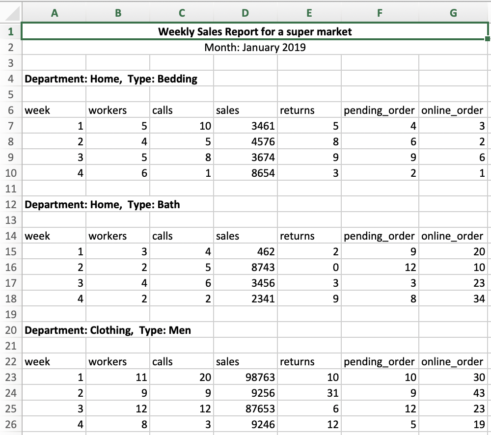

## Tidy data

```r
tidyDat <- read.csv("https://mamajumder.github.io/data-science/data/tidy-data.csv")
head(tidyDat[,1:8])
```

```
##   department    type week workers calls sales returns pending_order
## 1       home bedding    1       5    10  3461       5             4
## 2       home bedding    2       4     5  4576       8             6
## 3       home bedding    3       5     8  3674       9             9
## 4       home bedding    4       6     1  8654       3             2
## 5       home    Bath    1       3     4   462       2             9
## 6       home    Bath    2       2     5  8743       0            12
```

- Try `head(TidyDat)`

## Plotting Tidy data

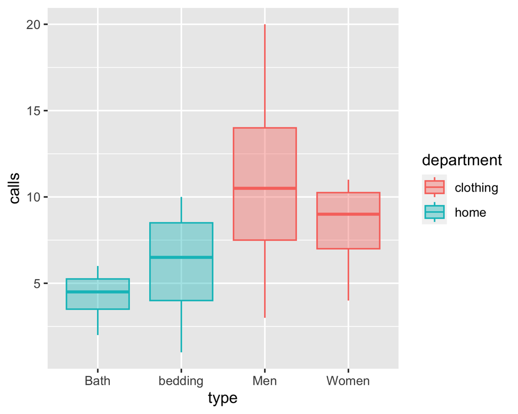

```r
library(ggplot2)
ggplot(tidyDat, aes(x = type, y = calls, color = department, fill = department)) +
  geom_boxplot(alpha = 0.4)
```

## Tidy text data

```
##   time water meat salt apples
## 1   10    40    5  3.0     20
## 2   11    25    3  2.5     11
## 3   14    20    3  2.0      4
```

- Other applications could be gleanihng data from Doctor’s prescriptions

## Wide vs long form data

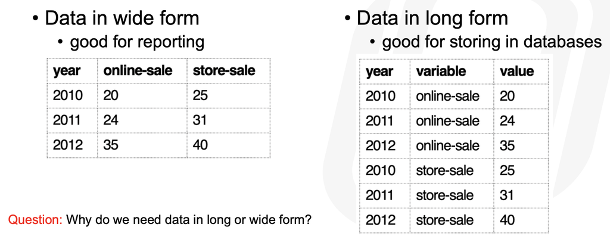

## Let us do it

- Read the wide form data

```r
wdat <- read.csv("https://mamajumder.github.io/data-science/data/wdat.csv")
```

- Load the package and convert to long form

```r
library(reshape2)
mdat <- melt(wdat, id = "year")
mdat
```

```
##   year    variable value
## 1 2010 online.sale    20
## 2 2011 online.sale    24
## 3 2012 online.sale    35
## 4 2010  store.sale    25
## 5 2011  store.sale    31
## 6 2012  store.sale    40
```

## Let us do it

- Now plot the long form data

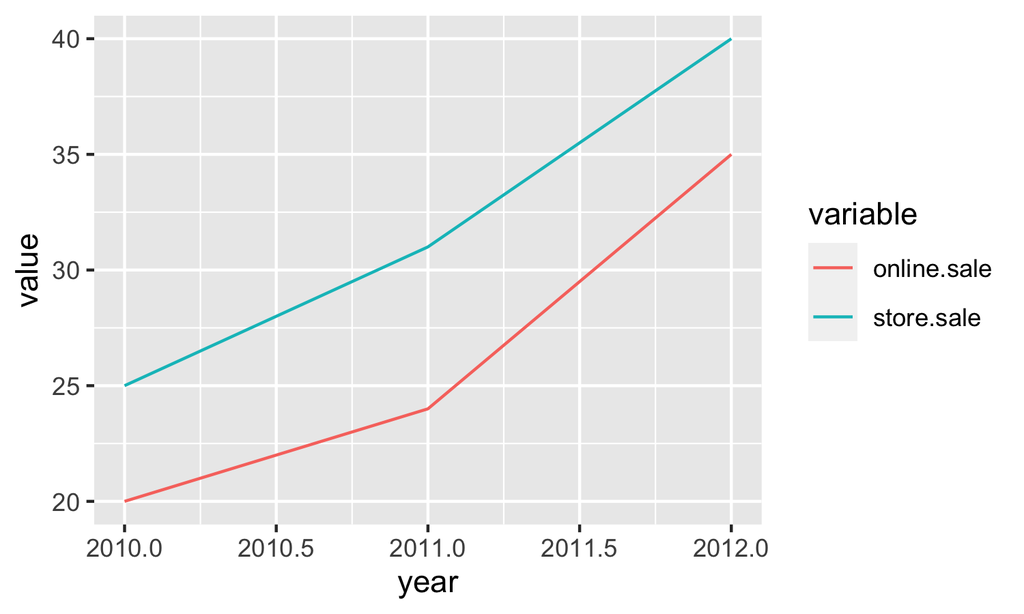

```r
ggplot(mdat, aes(x=year, y=value, color = variable)) +
  geom_line()
```

## Aggregating data

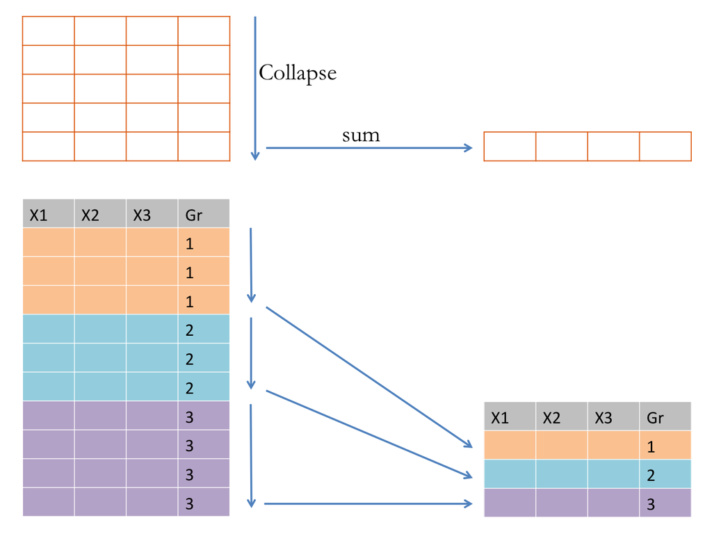

## Let us aggregate data

```r
library(dplyr)
avgSales <- mdat %>%
  group_by(variable) %>%
  summarise( avegrage.sales = mean(value))
kable(avgSales, format = "html", table.attr = "style='width:30%;'")
```

| variable | avegrage.sales |
| --- | --- |
| online.sale | 26.33333 |
| store.sale | 32.00000 |

## Transforming data

Notice the distribution of `X` is right skewed

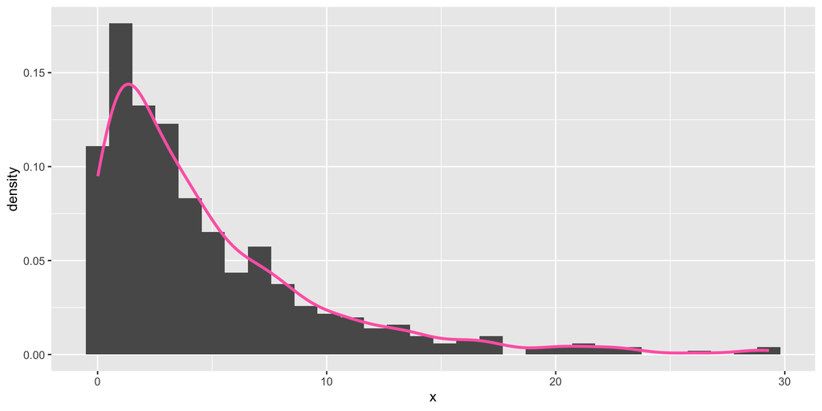

## Log transformation makes histogram symmetric

Notice the distribution of `log(X)`

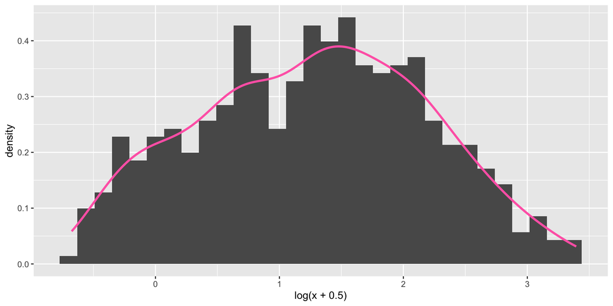

## Transforming data

- Relationship between `X` and `Y` does not seem to be linear

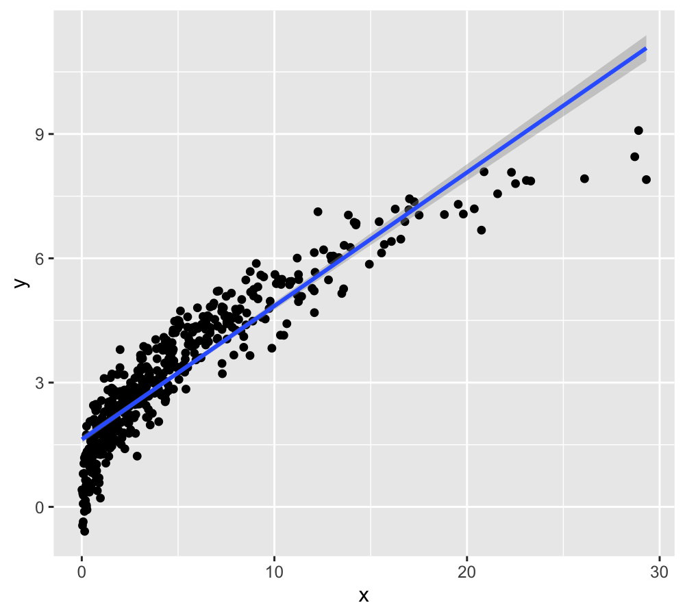

## Log transformation linearizes the relation

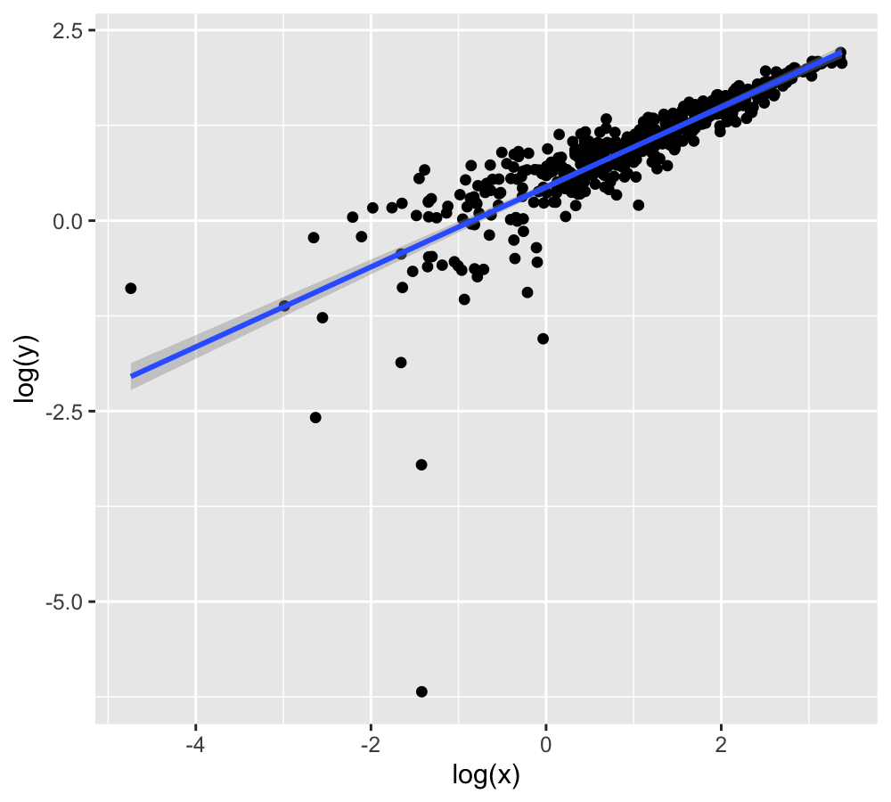

## Common transformations

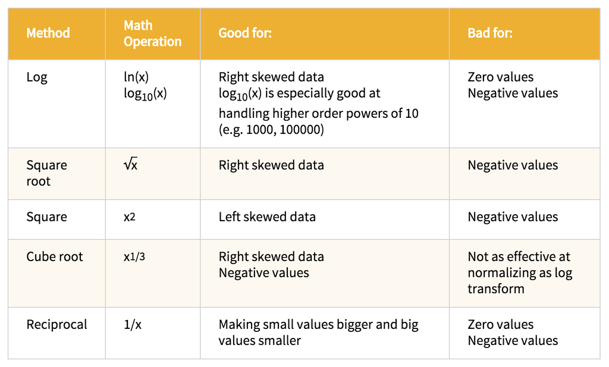

Source:  
https://infoactive.co/data-design/ch11.html

## Standardization of data

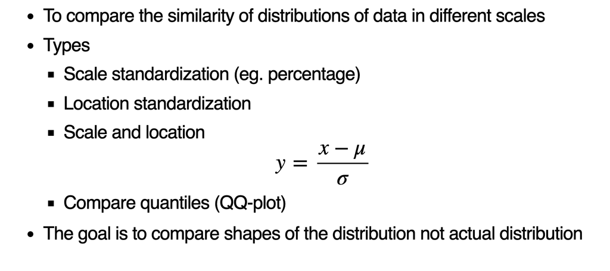